# bilibili数据分析

作为一位lv6老用户怎么能对b站的不了解呢？作为当前青年人最喜爱的视频网站有着许多非常有用的信息，当然B站也有很多有趣的机制。根据得到的有关B站2019年一月到2020年三月科技区数据，我们分析了那些up主更受观众喜欢（具体体现在播放量，点赞，投币，收藏，分享等），各季度视频产出数量以及视频播放量，产出量，点赞投币收藏之间横向对比，视频的点赞投币收藏的三者关系，白嫖视频排行榜，白嫖up主排行榜，那个小分区更受大众喜爱等多个数据分析。本次分析使用了numpy，pandas包用于数据分析，matplotlib.pyplot用于绘制图形，通过文字说明和图像对比直观形象的将数据分析结果呈现出来。

# 1. 数据预处理

首先导入数据，去掉数据中有缺失的部分和重复的部分。

```python
import numpy as np
import pandas as pd
from collections import Counter
import matplotlib.pyplot as plt
import seaborn as sns
import datetime
plt.rcParams['font.sans-serif']=['SimHei']
plt.rcParams['axes.unicode_minus']=False
df=pd.read_csv("科技区2019-1_2020-3.csv")
df.dropna(inplace=True)
df=df.drop_duplicates(["title","date","url"])
df=df.drop(["mid","url"],axis=1)
print(df)
```

```
           分区            bv   author            date  \
0        科学科普  BV1jb411H7aa     芳斯塔芙   3/14/19 16:50
1        科学科普  BV1vb411K737   黑白键伯辽兹   4/13/19 11:09
2        科学科普  BV1Ut411p7xq     嘿手视频   1/11/19 10:08
3        科学科普  BV1Nb411h7bc     芳斯塔芙   2/27/19 17:00
4        科学科普  BV1Sb411G726     芳斯塔芙   4/19/19 18:46
...       ...           ...      ...             ...
49354  野生技术协会  BV1JJ411a7Hg  R-A-F-A  12/29/19 11:36
49355  野生技术协会  BV16J411y7tM      薛凝蓝  12/10/19 16:55
50020      汽车  BV1WJ411Y7Va   白沙汽车空间   12/27/19 7:00
50126      汽车  BV1wJ411C78X     鸭哥说车  12/12/19 18:55
50127      汽车  BV1tJ411e7sd     车漫部落   12/29/19 7:30

                                    title     coins    danmu  favorite  \
0                   【鬼谷说】三叶虫：一个平凡家族的不屈与彷徨  102514.0  10851.0   39963.0
```

[output cut: 25 more lines]

# 2. 播放量，点赞，投币，收藏，分享，弹幕和评论数量前十多的视频，产出视频数量最多和收到投币数量最多的前十名up主

```
[Text(0.5, 1.0, '硬币数量前十阿婆主'), Text(0, 0.5, '阿婆主'), Text(0.5, 0, '硬币数')]
```

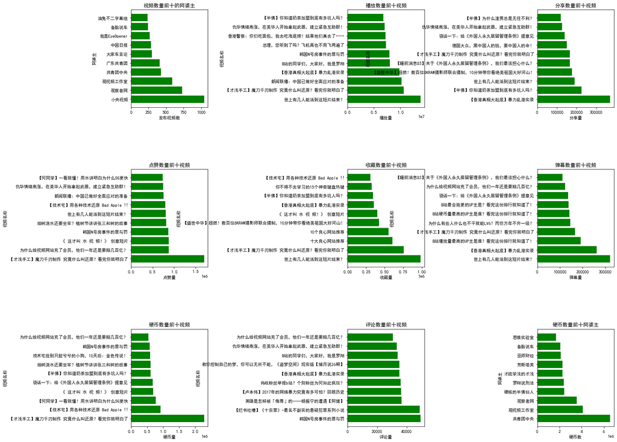

```python
plt.figure(figsize=(20,20))
ax1=plt.subplot2grid((9,18),(0,0),colspan=3,rowspan=2)
list1=df['author'].tolist()
list2=[]
list3=[]
list1=Counter(list1).most_common(10)
for i in list1:
    i=list(i)
    list2.append(i[0])
    list3.append(i[1])
ax1.barh(list2,list3,color='green')
ax1.set(title='视频数量前十的阿婆主',xlabel='发布视频数',ylabel='阿婆主')
ax2=plt.subplot2grid((9,18),(0,8),colspan=3,rowspan=2)
df2=df[['title','view']]
df2=df2.sort_values('view',ascending=False).head(10)
list2=df2['title'].tolist()
list3=df2['view'].tolist()
ax2.barh(list2,list3,color='green')
ax2.set(title='播放数量前十视频',xlabel='播放量',ylabel='视频名称')
ax3=plt.subplot2grid((9,18),(0,15),colspan=3,rowspan=2)
df2=df[['title','share']]
df2=df2.sort_values('share',ascending=False).head(10)
list2=df2['title'].tolist()
list3=df2['share'].tolist()
ax3.barh(list2,list3,color='green')
ax3.set(title='分享数量前十视频',xlabel='分享量',ylabel='视频名称')
ax4=plt.subplot2grid((9,18),(3,0),colspan=3,rowspan=2)
df2=df[['title','likes']]
df2=df2.sort_values('likes',ascending=False).head(10)
list2=df2['title'].tolist()
list3=df2['likes'].tolist()
ax4.barh(list2,list3,color='green')
ax4.set(title='点赞数量前十视频',xlabel='点赞量',ylabel='视频名称')
ax5=plt.subplot2grid((9,18),(3,8),colspan=3,rowspan=2)
df2=df[['title','favorite']]
df2=df2.sort_values('favorite',ascending=False).head(10)
list2=df2['title'].tolist()
list3=df2['favorite'].tolist()
ax5.barh(list2,list3,color='green')
ax5.set(title='收藏数量前十视频',xlabel='收藏量',ylabel='视频名称')
ax6=plt.subplot2grid((9,18),(3,15),colspan=3,rowspan=2)
df2=df[['title','danmu']]
df2=df2.sort_values('danmu',ascending=False).head(10)
list2=df2['title'].tolist()
list3=df2['danmu'].tolist()
ax6.barh(list2,list3,color='green')
ax6.set(title='弹幕数量前十视频',xlabel='弹幕量',ylabel='视频名称')
ax7=plt.subplot2grid((9,18),(6,0),colspan=3,rowspan=2)
df2=df[['title','coins']]
df2=df2.sort_values('coins',ascending=False).head(10)
list2=df2['title'].tolist()
list3=df2['coins'].tolist()
ax7.barh(list2,list3,color='green')
ax7.set(title='硬币数量前十视频',xlabel='硬币量',ylabel='视频名称')
ax8=plt.subplot2grid((9,18),(6,8),colspan=3,rowspan=2)
df2=df[['title','replay']]
df2=df2.sort_values('replay',ascending=False).head(10)
list2=df2['title'].tolist()
list3=df2['replay'].tolist()
ax8.barh(list2,list3,color='green')
ax8.set(title='评论数量前十视频',xlabel='评论量',ylabel='视频名称')
ax9=plt.subplot2grid((9,18),(6,15),colspan=3,rowspan=2)
coinss=df.groupby('author')['coins'].sum().sort_values(ascending=False)[0:10]
ax9.barh(coinss.index,coinss,color='green')
ax9.set(title='硬币数量前十阿婆主',ylabel='阿婆主',xlabel='硬币数')
```

# 3.1各个季度产出视频数量和对应的观看，投币，弹幕，评论等的数量关系。

```
0        2019-03-14 16:50:00
1        2019-04-13 11:09:00
2        2019-01-11 10:08:00
3        2019-02-27 17:00:00
4        2019-04-19 18:46:00
                ...
49354    2019-12-29 11:36:00
49355    2019-12-10 16:55:00
50020    2019-12-27 07:00:00
50126    2019-12-12 18:55:00
50127    2019-12-29 07:30:00
Name: date, Length: 31350, dtype: object
```

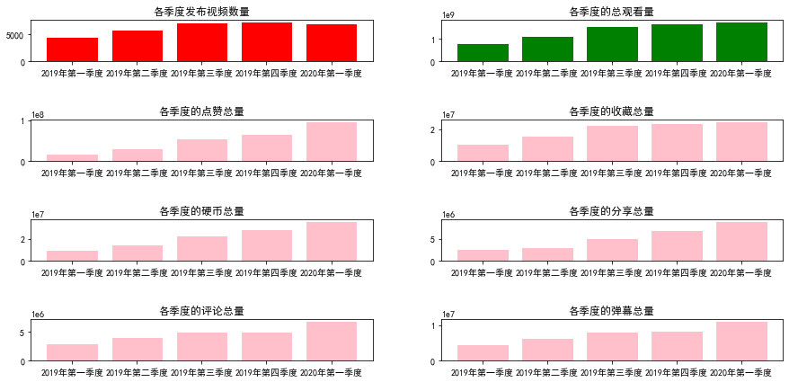

```python
plt.figure(figsize=(15,8))
gindex=df.index
for i in gindex:
    k=list(df.at[i,'date'])
    t=0
    for j in range(len(k)):
        if k[j]!='/':
            t+=1
        else:
            if t==1:
                k[j-1]='0'+k[j-1]
            t=0
        if j==len(k)-1:
            k[j]=k[j]+":00"
    k="".join(k)
    df.at[i,'date']=datetime.datetime.strptime(k, '%m/%d/%y %H:%M:%S')
print(df["date"])
df=df.sort_values('date')
df1=df[df['date']<datetime.datetime(2019,4,1,0,0)]
df2=df[df['date']<datetime.datetime(2019,7,1,0,0)]
df2=df2[df2['date']>=datetime.datetime(2019,4,1,0,0)]
df3=df[df['date']<datetime.datetime(2019,10,1,0,0)]
df3=df3[df3['date']>=datetime.datetime(2019,7,1,0,0)]
df4=df[df['date']<datetime.datetime(2020,1,1,0,0)]
df4=df4[df4['date']>=datetime.datetime(2019,10,1,0,0)]
df5=df[df['date']>datetime.datetime(2020,1,1,0,0)]
d1=[len(df1),len(df2),len(df3),len(df4),len(df5)]
d2=[df1['view'].sum(),df2['view'].sum(),df3['view'].sum(),df4['view'].sum(),df5['view'].sum()]
d3=[df1['likes'].sum(),df2['likes'].sum(),df3['likes'].sum(),df4['likes'].sum(),df5['likes'].sum()]
d4=[df1['favorite'].sum(),df2['favorite'].sum(),df3['favorite'].sum(),df4['favorite'].sum(),df5['favorite'].sum()]
d5=[df1['coins'].sum(),df2['coins'].sum(),df3['coins'].sum(),df4['coins'].sum(),df5['coins'].sum()]
d6=[df1['share'].sum(),df2['share'].sum(),df3['share'].sum(),df4['share'].sum(),df5['share'].sum()]
d7=[df1['replay'].sum(),df2['replay'].sum(),df3['replay'].sum(),df4['replay'].sum(),df5['replay'].sum()]
d8=[df1['danmu'].sum(),df2['danmu'].sum(),df3['danmu'].sum(),df4['danmu'].sum(),df5['danmu'].sum()]
k=["2019年第一季度","2019年第二季度","2019年第三季度","2019年第四季度","2020年第一季度"]
adx1=plt.subplot2grid((8,2),(0,0),colspan=1,rowspan=1)
adx1.bar(k,d1,facecolor='red',edgecolor='white')
plt.title('各季度发布视频数量')
adx2=plt.subplot2grid((8,2),(0,1),colspan=1,rowspan=1)
adx2.bar(k,d2,facecolor='green',edgecolor='white')
plt.title('各季度的总观看量')
adx3=plt.subplot2grid((8,2),(2,0),colspan=1,rowspan=1)
adx3.bar(k,d3,facecolor='pink',edgecolor='white')
plt.title('各季度的点赞总量')
adx4=plt.subplot2grid((8,2),(2,1),colspan=1,rowspan=1)
adx4.bar(k,d4,facecolor='pink',edgecolor='white')
plt.title('各季度的收藏总量')
adx5=plt.subplot2grid((8,2),(4,0),colspan=1,rowspan=1)
adx5.bar(k,d5,facecolor='pink',edgecolor='white')
plt.title('各季度的硬币总量')
adx6=plt.subplot2grid((8,2),(4,1),colspan=1,rowspan=1)
adx6.bar(k,d6,facecolor='pink',edgecolor='white')
plt.title('各季度的分享总量')
adx7=plt.subplot2grid((8,2),(6,0),colspan=1,rowspan=1)
adx7.bar(k,d7,facecolor='pink',edgecolor='white')
plt.title('各季度的评论总量')
adx8=plt.subplot2grid((8,2),(6,1),colspan=1,rowspan=1)
adx8.bar(k,d8,facecolor='pink',edgecolor='white')
plt.title('各季度的弹幕总量')
```

# 3.2 我们使用扇形分布图更好的来理解2019年各个季度视频产出量

使用扇形统计图来更好的理解2019年各季度视频的产出数量对比

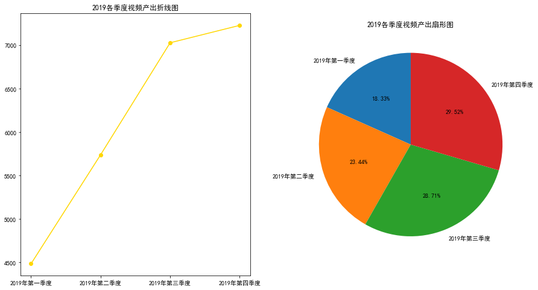

```python
plt.figure(figsize=(15,8))
adx9=plt.subplot2grid((1,2),(0,0),colspan=1,rowspan=1)
d9=[len(df1),len(df2),len(df3),len(df4)]
k1=["2019年第一季度","2019年第二季度","2019年第三季度","2019年第四季度"]
adx9.plot(k1,d9,"o-",color='gold')
plt.title('2019各季度视频产出折线图')
adx10=plt.subplot2grid((1,2),(0,1),colspan=1,rowspan=1)
adx10.pie(d9,labels=k1,autopct="%0.2f%%",startangle=90)
plt.title('2019各季度视频产出扇形图')
```

# 3.3 一键三连是b站的特色，让我们看看所有视频得到的点赞投币收藏的数量分布。

点赞投币收藏总体是互相呈正相关的

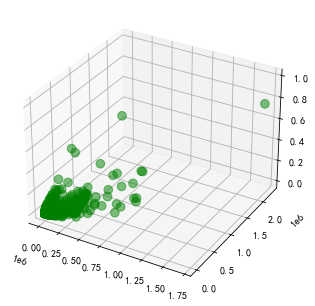

```python
from mpl_toolkits.mplot3d import Axes3D
fig=plt.figure()
ax=Axes3D(fig)
X3D=df['likes'].tolist()
Y3D=df['coins'].tolist()
Z3D=df['favorite'].tolist()
ax.scatter(X3D,Y3D,Z3D,c='green',s=75,alpha=0.5)
```

# 3.4 被白嫖视频排行榜

```python
df['白嫖率']=(df['view']-df['coins']-df['likes']-df['favorite']-df['share'])/df['view']
dfbaipiao=df[['title','白嫖率']].sort_values('白嫖率',ascending=False)[0:10]
print(dfbaipiao)
```

```
                                 title       白嫖率
22153                              客车6  1.000000
22155                              好车6  1.000000
22156                              好车5  1.000000
10767   不辜负每一程的相遇，曹操出行祝全国人民新春快乐，阖家安康！4  0.999982
38832           插混双擎，乐享出行；丰田品质，都市新秀首选。  0.999980
22317                             奔驰A级  0.999939
38826             《侃侃2谈》-二十二期 0元也能买奔驰？  0.999922
2997   动漫中的日本女生和现实中的日本女生的差别巨大？！只因为这一句话  0.999913
28869               别眨眼 东方明珠九号卡丁酷玩节快闪版  0.999888
24036   全车都是黑科技，30万买MARVEL X值吗？ | 麻辣视频  0.999800
```

# 3.5 让我康康哪位阿婆主最容易让人白嫖视频

```python
dfbaipiaoup2=df.groupby('author')['白嫖率'].mean().sort_values(ascending=False).head(10)
print(dfbaipiaoup2)
```

```
author
爱吃豆子的大松鼠     1.000000
Autovideo    0.999980
Yc丶y         0.999939
侃侃2谈         0.999922
bix5623      0.999913
爱吃芒果娱乐       0.999888
爱老婆的欢喜       0.999506
如果想念有声音丶     0.999286
蓝星美容师        0.999272
K1李美丫        0.999225
Name: 白嫖率, dtype: float64
```

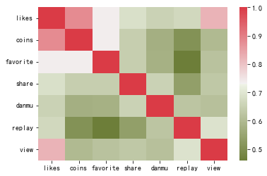

```python
plt.figure()
dfw=df[['likes','coins','favorite','share','danmu','replay','view']].corr()
T1=sns.diverging_palette(100,10,as_cmap=True)
sns.heatmap(dfw,cmap=T1)
```

# 3.6 那种分区的视频更受观众喜欢

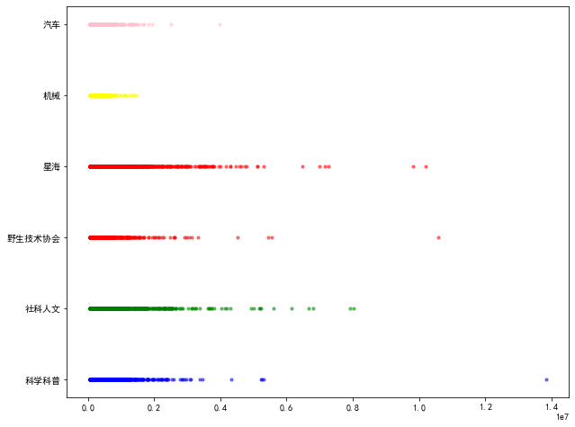

```python
plt.figure(figsize=(10,8))
listw1=[]
lists1=[]
listw2=[]
lists2=[]
listw3=[]
lists3=[]
listw4=[]
lists4=[]
listw5=[]
lists5=[]
listw6=[]
lists6=[]
colors = ['blue', 'green', 'red','yellow','pink','black']
for i in df.index:
    if(df['分区'][i]=='科学科普'):
        listw1.append(df['view'][i])
        lists1.append('科学科普')
    if(df['分区'][i]=='社科人文'):
        listw2.append(df['view'][i])
        lists2.append('社科人文')
    if(df['分区'][i]=='野生技术协会'):
        listw3.append(df['view'][i])
        lists3.append('野生技术协会')
    if(df['分区'][i]=='星海'):
        listw3.append(df['view'][i])
        lists3.append('星海')
    if(df['分区'][i]=='机械'):
        listw4.append(df['view'][i])
        lists4.append('机械')
    if(df['分区'][i]=='汽车'):
        listw5.append(df['view'][i])
        lists5.append('汽车')
plt.scatter(listw1,lists1,c=colors[0],alpha=0.5,s=10)
plt.scatter(listw2,lists2,c=colors[1],alpha=0.5,s=10)
plt.scatter(listw3,lists3,c=colors[2],alpha=0.5,s=10)
plt.scatter(listw4,lists4,c=colors[3],alpha=0.5,s=10)
plt.scatter(listw5,lists5,c=colors[4],alpha=0.5,s=10)
plt.scatter(listw6,lists6,c=colors[5],alpha=0.5,s=10)
```

# 4 我们想使用K-means聚类算法根据视频火热程度将视频分为四类（冷门，中等，热门，超火爆），而评测视频火热程度的参数选取了点赞，投币和评论数量来进行预测。最终画出三维的聚类图像。

首先我们先创建三维窗口界面，取出硬币，点赞，评论的所有数据。

```python
from sklearn.cluster import KMeans
from mpl_toolkits.mplot3d import Axes3D

X = np.array(list(zip(df['coins'].head(30000), df['likes'].head(30000),df['replay'].head(30000)))).reshape(30000, 3)
print(X)
```

```
[[1.6000e+01 1.7300e+02 3.5700e+02]
 [2.1100e+02 1.2590e+03 1.0590e+03]
 [6.8000e+01 3.8600e+02 2.6600e+02]
 ...
 [5.2640e+03 8.3840e+03 3.1900e+02]
 [4.6820e+03 1.8116e+04 9.8200e+02]
 [2.3900e+02 3.6800e+03 4.2200e+02]]
```

我们设置不同类别的颜色，形状，并将三组数据存入到三个列表中用于之后的绘制。 由于导出页面限制，我们只展示前1000个数据

```python
colors = ['b', 'g', 'r', 'y']
markers = ['+', '+', 'x','x']
list11=[]
list22=[]
list33=[]
for i in df['replay'].head(30000).index:
    list11.append(df['replay'][i])
for i in df['coins'].head(30000).index:
    list22.append(df['coins'][i])
for i in df['likes'].head(30000).index:
    list33.append(df['likes'][i])
print(list11[0:1000])
print(list22[0:1000])
print(list33[0:1000])
```

[output not shown]

使用sklearn中提供的k-means函数，将所有数据进行聚类运算。由于导出页面限制，我们只展示前1000个数据

```python
K = 4
kmeans_model = KMeans(n_clusters=K).fit(X)
print(list(enumerate(kmeans_model.labels_))[0:1000])
```

[output not shown]

绘制三维图像

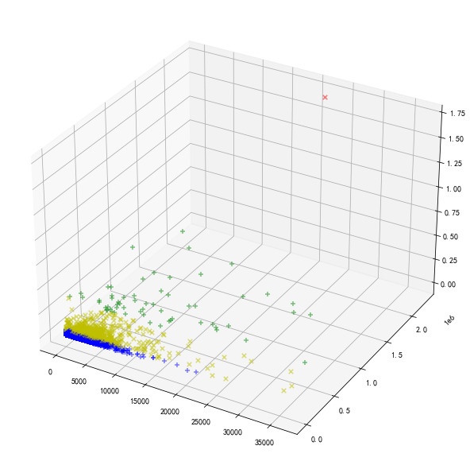

```python
fig2=plt.figure(figsize=(10,8))
ax2=Axes3D(fig2)
for i, l in enumerate(kmeans_model.labels_):
    ax2.scatter(list11[i],list22[i],list33[i],c=colors[l],marker=markers[l],s=30,alpha=0.5)
```

我们看到图像数据被分为四类，其中蓝色部分数量很多，其次是黄色部分，而绿色部分数量略显稀疏，红色部分数量极少。 相应的我们看到数量多的部分都是点赞，投币评论数量相对较少的，而数量少的部分则点赞，投币和评论数量都比较高，这与B站视频热门程度分布情况大致相同。

# 5 数据结论